# Traitement des valeurs manquantes

## Visualisation des valeurs manquantes

### Installation des packages et import des libraries

```r
#install.packages("https://cran.r-project.org/bin/windows/contrib/3.6/foreign_0.8-76.zip")
#install.packages("VIM")
library(VIM)
```

```r
df_trous<-df_filt2[,vars_trous]
df_filt2[,c("Date_Heure_Locale",vars_trous)]
```

| Date_Heure_Locale | temperature | no | no2 | humidite | particules_fines | ext_pm25 | ext_pm10 | ext_o3 | ext_no2 |
| --- | --- | --- | --- | --- | --- | --- | --- | --- | --- |
| 2014-01-01 01:00:00 | 13.5 | 3 | 30 | 62.1 | 47 | 43 | 30 | 22 | 42 |
| 2014-01-01 02:00:00 | 13.6 | 6 | 41 | 61.2 | 38 | 43 | 30 | 22 | 42 |
| 2014-01-01 03:00:00 | 13.4 | 31 | 52 | 61.0 | 40 | 43 | 30 | 22 | 42 |
| 2014-01-01 04:00:00 | 13.3 | 33 | 70 | 59.6 | 33 | 43 | 30 | 22 | 42 |
| 2014-01-01 05:00:00 | 13.3 | 18 | 53 | 58.8 | 29 | 43 | 30 | 22 | 42 |
| 2014-01-01 06:00:00 | 13.3 | 13 | 48 | 58.2 | 19 | 43 | 30 | 22 | 42 |
| 2014-01-01 07:00:00 | 13.3 | 13 | 47 | 58.4 | 19 | 43 | 30 | 22 | 42 |
| 2014-01-01 08:00:00 | 13.1 | 31 | 56 | 59.7 | 22 | 43 | 30 | 22 | 42 |
| 2014-01-01 09:00:00 | 12.9 | 7 | 35 | 60.7 | 14 | 43 | 30 | 22 | 42 |
| 2014-01-01 10:00:00 | 12.8 | 9 | 36 | 62.6 | 17 | 43 | 30 | 22 | 42 |
| 2014-01-01 11:00:00 | 12.8 | 12 | 41 | 63.3 | 16 | 43 | 30 | 22 | 42 |
| 2014-01-01 12:00:00 | 12.9 | 5 | 29 | 63.9 | 14 | 43 | 30 | 22 | 42 |
| 2014-01-01 13:00:00 | 13.1 | 9 | 36 | 62.8 | 9 | 43 | 30 | 22 | 42 |
| 2014-01-01 14:00:00 | 13.3 | 13 | 42 | 62.9 | 14 | 43 | 30 | 22 | 42 |
| 2014-01-01 15:00:00 | 13.5 | 13 | 41 | 62.5 | 17 | 43 | 30 | 22 | 42 |
| 2014-01-01 16:00:00 | 13.6 | 17 | 44 | 62.9 | 20 | 43 | 30 | 22 | 42 |
| 2014-01-01 17:00:00 | 13.9 | 25 | 51 | 62.4 | 20 | 43 | 30 | 22 | 42 |
| 2014-01-01 18:00:00 | 14.0 | 46 | 62 | 62.2 | 26 | 43 | 30 | 22 | 42 |
| 2014-01-01 19:00:00 | 14.1 | 58 | 64 | 65.2 | 31 | 43 | 30 | 22 | 42 |
| 2014-01-01 20:00:00 | 14.1 | 66 | 68 | 66.7 | 25 | 43 | 30 | 22 | 42 |
| 2014-01-01 21:00:00 | 14.2 | 30 | 50 | 65.9 | 20 | 43 | 30 | 22 | 42 |
| 2014-01-01 22:00:00 | 14.2 | 16 | 43 | 65.0 | 24 | 43 | 30 | 22 | 42 |
| 2014-01-01 23:00:00 | 14.2 | 11 | 34 | 64.6 | 19 | 43 | 30 | 22 | 42 |
| 2014-01-02 00:00:00 | 14.3 | 8 | 28 | 65.8 | 27 | 43 | 30 | 22 | 42 |
| 2014-01-02 01:00:00 | 14.3 | 3 | 20 | 65.3 | 24 | 53 | 33 | 22 | 34 |
| 2014-01-02 02:00:00 | 14.0 | 3 | 14 | 67.3 | 34 | 53 | 33 | 22 | 34 |
| 2014-01-02 03:00:00 | 14.5 | NA | 12 | 64.6 | 19 | 53 | 33 | 22 | 34 |
| 2014-01-02 04:00:00 | 14.4 | NA | 10 | 62.6 | NA | 53 | 33 | 22 | 34 |
| 2014-01-02 05:00:00 | 14.2 | NA | 10 | 62.2 | 5 | 53 | 33 | 22 | 34 |
| 2014-01-02 06:00:00 | 14.3 | 2 | 17 | 65.0 | 18 | 53 | 33 | 22 | 34 |
| ... | ... | ... | ... | ... | ... | ... | ... | ... | ... |
| 2019-12-30 19:00:00 | 14.5 | 182 | 74 | 41.0 | 90 | NA | NA | NA | NA |
| 2019-12-30 20:00:00 | 14.8 | 218 | 79 | 41.0 | 89 | NA | NA | NA | NA |
| 2019-12-30 21:00:00 | 14.6 | 229 | 79 | 41.7 | 98 | NA | NA | NA | NA |
| 2019-12-30 22:00:00 | 14.8 | 198 | 73 | 40.6 | 76 | NA | NA | NA | NA |
| 2019-12-30 23:00:00 | 16.2 | 202 | 76 | 37.0 | 78 | NA | NA | NA | NA |
| 2019-12-31 00:00:00 | 16.3 | 193 | 75 | 36.4 | 53 | NA | NA | NA | NA |
| 2019-12-31 01:00:00 | 16.4 | 174 | 79 | 36.2 | 54 | NA | 36 | 2 | 24 |
| 2019-12-31 02:00:00 | 16.1 | 247 | 79 | 36.8 | 59 | NA | 36 | 2 | 24 |
| 2019-12-31 03:00:00 | 16.1 | 246 | 73 | 36.1 | 57 | NA | 36 | 2 | 24 |
| 2019-12-31 04:00:00 | 15.3 | 185 | 63 | 37.4 | 52 | NA | 36 | 2 | 24 |
| 2019-12-31 05:00:00 | 15.0 | 135 | 52 | 37.6 | 48 | NA | 36 | 2 | 24 |
| 2019-12-31 06:00:00 | 15.1 | 111 | 47 | 37.0 | 37 | NA | 36 | 2 | 24 |
| 2019-12-31 07:00:00 | 14.5 | 110 | 45 | 38.2 | 35 | NA | 36 | 2 | 24 |
| 2019-12-31 08:00:00 | 14.2 | 119 | 43 | 39.3 | 37 | NA | 36 | 2 | 24 |
| 2019-12-31 09:00:00 | 12.5 | 116 | 41 | 43.1 | 39 | NA | 36 | 2 | 24 |
| 2019-12-31 10:00:00 | 11.8 | 133 | 45 | 45.0 | 58 | NA | 36 | 2 | 24 |
| 2019-12-31 11:00:00 | 12.0 | 177 | 50 | 44.5 | 61 | NA | 36 | 2 | 24 |
| 2019-12-31 12:00:00 | 12.2 | 148 | 45 | 43.4 | 57 | NA | 36 | 2 | 24 |
| 2019-12-31 13:00:00 | 13.7 | 148 | 51 | 40.2 | 51 | NA | 36 | 2 | 24 |
| 2019-12-31 14:00:00 | 14.4 | 153 | 62 | 38.7 | 54 | NA | 36 | 2 | 24 |
| 2019-12-31 15:00:00 | 14.8 | 131 | 58 | 38.3 | 53 | NA | 36 | 2 | 24 |
| 2019-12-31 16:00:00 | 15.1 | 121 | 56 | 39.1 | 52 | NA | 36 | 2 | 24 |
| 2019-12-31 17:00:00 | 15.3 | 107 | 54 | 40.1 | 65 | NA | 36 | 2 | 24 |
| 2019-12-31 18:00:00 | 14.8 | 121 | 56 | 42.9 | 78 | NA | 36 | 2 | 24 |
| 2019-12-31 19:00:00 | 13.8 | 111 | 52 | 45.3 | 75 | NA | 36 | 2 | 24 |
| 2019-12-31 20:00:00 | 13.6 | 80 | 50 | 44.7 | 79 | NA | 36 | 2 | 24 |
| 2019-12-31 21:00:00 | 13.4 | 63 | 48 | 44.9 | 54 | NA | 36 | 2 | 24 |
| 2019-12-31 22:00:00 | 13.6 | 50 | 45 | 44.1 | 112 | NA | 36 | 2 | 24 |
| 2019-12-31 23:00:00 | 14.3 | 46 | 46 | 40.9 | 115 | NA | 36 | 2 | 24 |
| 2020-01-01 00:00:00 | 14.7 | 81 | 51 | 40.5 | 57 | NA | 36 | 2 | 24 |

```
 Variables sorted by number of missings:
         Variable       Count
           ext_o3 0.063087686
         ext_pm10 0.060170926
          ext_no2 0.060170926
         ext_pm25 0.059824179
               no 0.040487894
 particules_fines 0.031839599
              no2 0.030962531
         humidite 0.007383687
      temperature 0.007200114
```

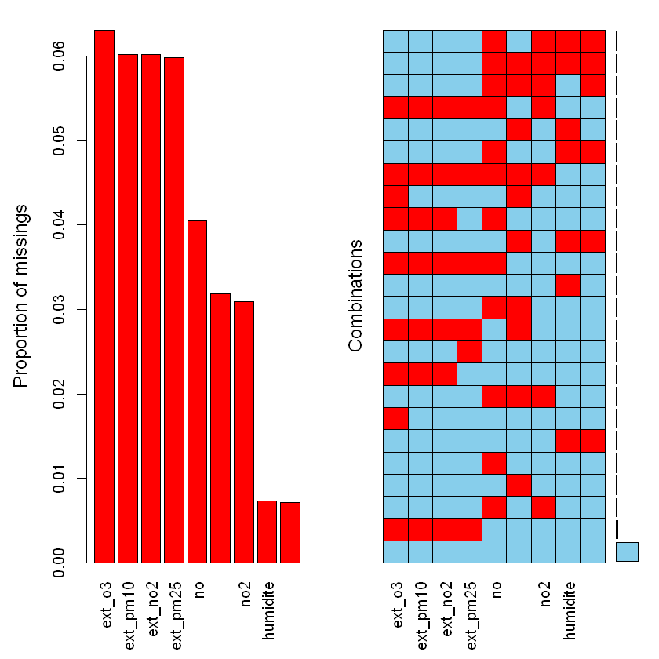

```r
res<-summary(aggr(df_trous,sortVar=TRUE))$combinations
```

```r
head(res[rev(order(res[,2])),])
```

|  | Combinations | Count | Percent |
| --- | --- | --- | --- |
| 1 | 0:0:0:0:0:0:0:0:0 | 42193 | 86.0607420 |
| 5 | 0:0:0:0:0:1:1:1:1 | 2737 | 5.5826381 |
| 15 | 0:1:1:0:0:0:0:0:0 | 1373 | 2.8004977 |
| 6 | 0:0:0:0:1:0:0:0:0 | 1298 | 2.6475208 |
| 11 | 0:1:0:0:0:0:0:0:0 | 404 | 0.8240357 |
| 19 | 1:0:0:1:0:0:0:0:0 | 338 | 0.6894160 |

Influence de l'absence des valeurs d'un variable dans d'autres variables

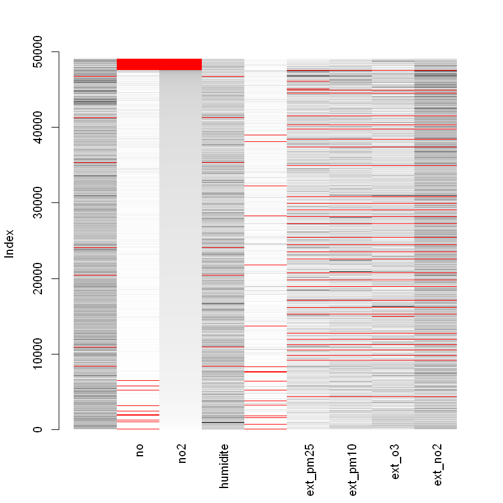

```r
matrixplot(df_trous,sortby = 3)
```

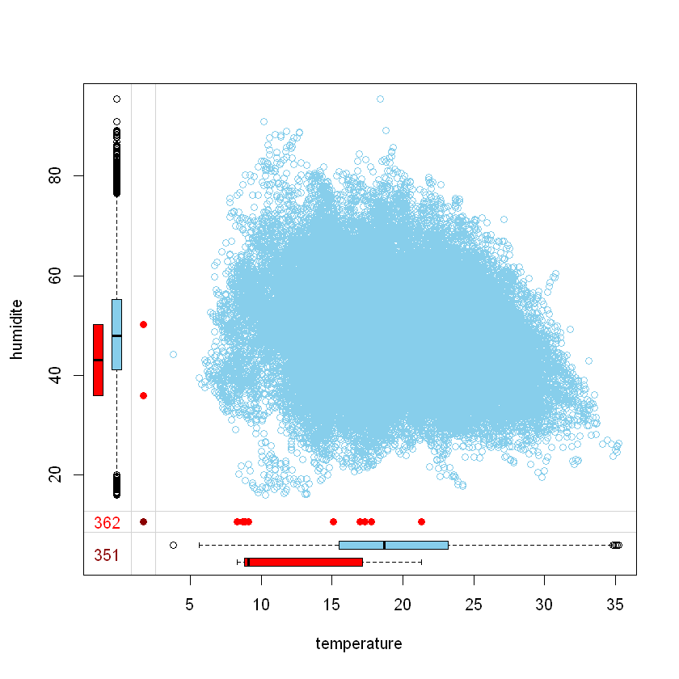

```r
marginplot(df_trous[,c("temperature","humidite")])
```

Beaucoup de différence entre la température quand il manque l'humidité et quand elle est présente. Valeurs manquantes MAR ??

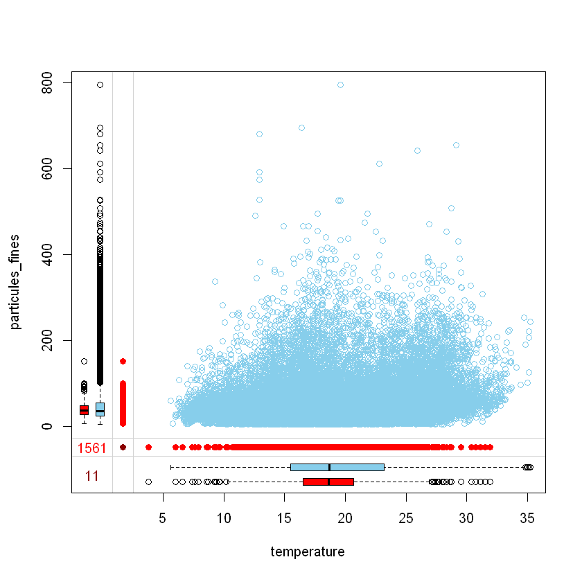

```r
marginplot(df_trous[,c("temperature","particules_fines")])
```

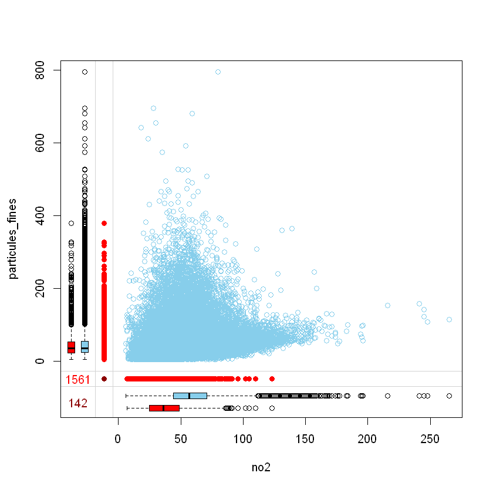

```r
marginplot(df_trous[,c("no2","particules_fines")])
```

Valeurs manquantes MAR ?

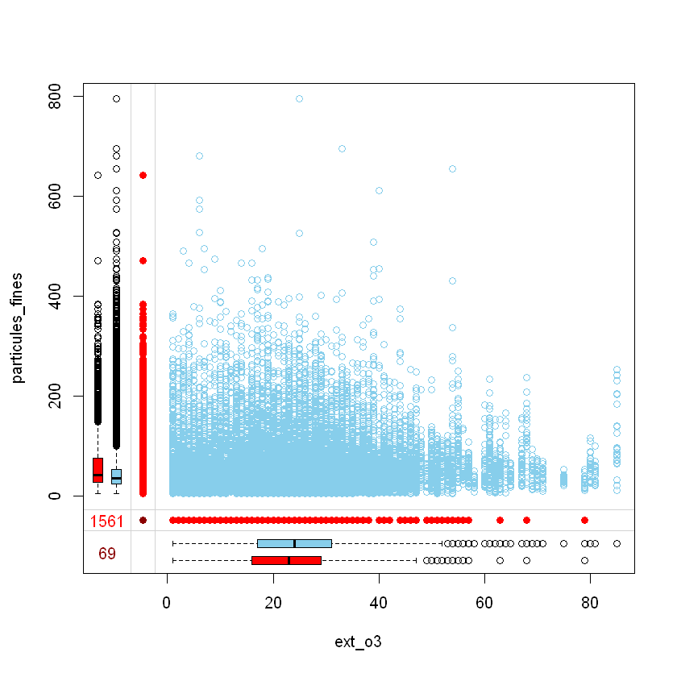

```r
marginplot(df_trous[,c("ext_o3","particules_fines")])
```

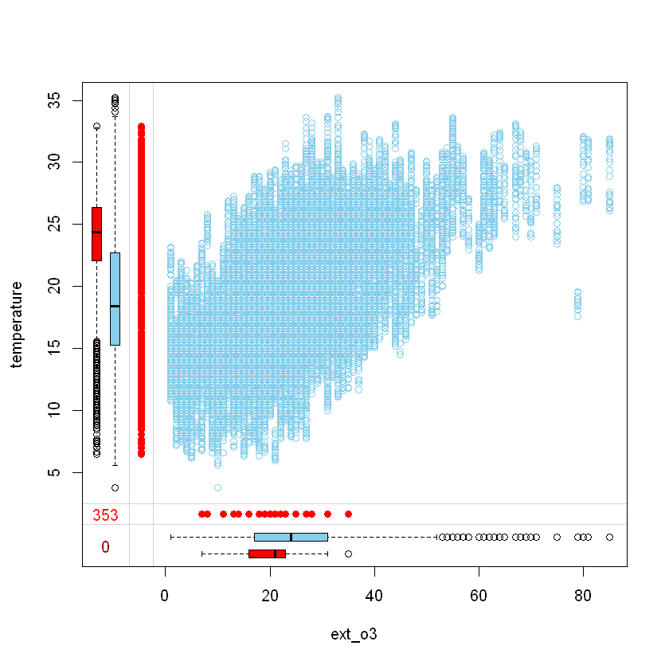

```r
marginplot(df_trous[,c("ext_o3","temperature")])
```

#### Analyse de correspondance multiple :

Préparation de la matrix de correspondance

```r
tabNA<-matrix("p",nrow=nrow(df_trous),ncol=ncol(df_trous))
tabNA[is.na(df_trous)]<-"a"
dimnames(tabNA)<-dimnames(df_trous)
```

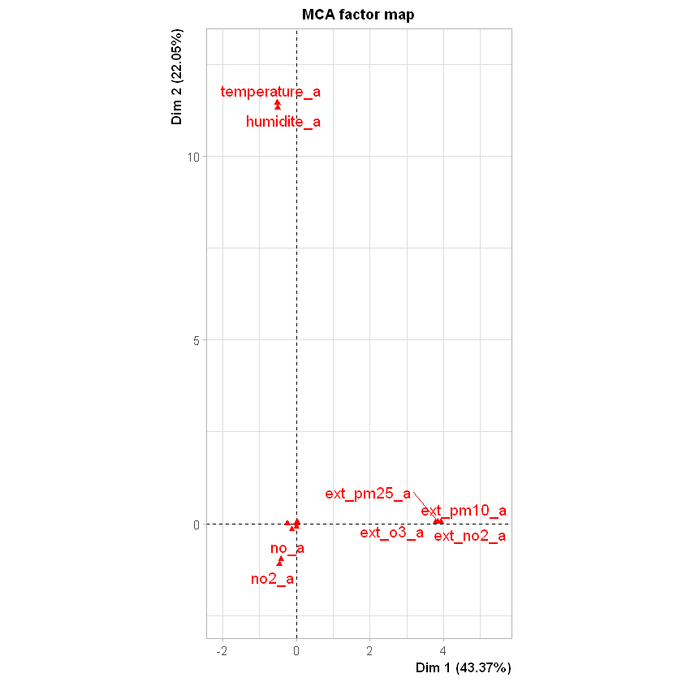

```r
res.mca<-MCA(tabNA,graph=FALSE)
plot(res.mca,invisible="ind")
```

# Imputations des valeurs manquantes.

Nous allons adopter deux stratégies différentes, supprimer les 14% des valeurs manquantes ou l'imputation à travers des différentes méthodes de ces valeurs.

Chaque stratégie aura comme résultat un fichier différent afin de tester les modèles avec les deux stratégies différentes.

## Suppression des valeurs manquantes

```r
df_clean<-drop_na(df_filt2)
nrow(df_clean)*100/nrow(df_filt2)
```

86.0607420401004

## Imputation des valeurs

### Imputation par RF

```r
#install.packages("missForest")
#install.packages("missMDA")
library(missForest)
library(missMDA)
```

```r
IMPUT_RF=FALSE
if (IMPUT_RF==TRUE)
{
    df_impt_RF<-missForest(df_filt2[vars_trous])
}
```

### Imputation par PCA

```r
IMPUT_PCA=TRUE
if (IMPUT_PCA==TRUE)
{
    nb<-estim_ncpPCA(df_filt2[vars_trous])
    df_impt_PCA<-imputePCA(df_filt2[vars_trous],ncp=nb$ncp)
}
```

[output not shown]

```r
df_impt_PCA$completeObs[290:300,]
```

| temperature | no | no2 | humidite | particules_fines | ext_pm25 | ext_pm10 | ext_o3 | ext_no2 |
| --- | --- | --- | --- | --- | --- | --- | --- | --- |
| 12.6 | 98 | 93 | 48.6 | 39 | 62 | 28 | 15 | 48 |
| 11.3 | 105 | 77 | 63.5 | 42 | 66 | 23 | 21 | 46 |
| 11.6 | 93 | 70 | 63.1 | 47 | 66 | 23 | 21 | 46 |
| 12.4 | 72 | 71 | 65.2 | 27 | 66 | 23 | 21 | 46 |
| 12.6 | 67 | 69 | 66.2 | 27 | 66 | 23 | 21 | 46 |
| 12.8 | 103 | 77 | 67.3 | 28 | 66 | 23 | 21 | 46 |
| 12.8 | 113 | 81 | 68.0 | 34 | 66 | 23 | 21 | 46 |
| 12.7 | 105 | 73 | 69.0 | 33 | 66 | 23 | 21 | 46 |
| 12.9 | 106 | 75 | 70.6 | 37 | 66 | 23 | 21 | 46 |
| 13.1 | 86 | 69 | 70.8 | 37 | 66 | 23 | 21 | 46 |
| 13.3 | 67 | 64 | 71.3 | 34 | 66 | 23 | 21 | 46 |

## Ecriture des données en disque

```r
write.csv(df_clean,paste(DATA_PATH,DATA_FILE_OUT_CLEAN,sep=""))
```

```r
if (IMPUT_RF==TRUE)
{
    write.csv(df_impt_RF,paste(DATA_PATH,DATA_FILE_OUT_RF,sep=""))
}
```

```r
if (IMPUT_PCA==TRUE)
{
    write.csv(df_impt_PCA,paste(DATA_PATH,DATA_FILE_OUT_PCA,sep=""))
}
```